# Section 2: DESeq2 analysis

## DESeq2 analyses steps

This section uses the count data (for selected datasets) generated in Section 1 to do differential expression (DE) analyses using `DESeq2`. Briefly, the count data are imported in R, batch corrected using `ComBat_seq`, then DE analyses were performed for various contrasts using `DESeq2`. Results were visualized as volcano plots, and cell enrichment performed using `PlacentaCellEnrich` (`PCE`).

## Prerequisites

R packages required for this section are loaded

```r
setwd("C:/Users/arun/OneDrive - Iowa State University/OrganizedDocuments/github/BAPvsTrophoblast_Amnion")
# load the modules
library(sva)
library(tidyverse)
library(DESeq2)
library(vsn)
library(pheatmap)
library(ggrepel)
library(RColorBrewer)
library(reshape2)
require(biomaRt)
library(EnhancedVolcano)
library(TissueEnrich)
library(plotly)
library(DT)
library(cowplot)
library(biomaRt)
library(tidytext)
library(ggpubr)
library(scales)
```

## Import datasets

The `counts` data and its associated metadata (`coldata`) are imported for analyses.

```r
counts = 'assets/counts-subset-v5.txt'
groupFile = 'assets/batch-subset-v5.txt'
coldata <-
  read.csv(
    groupFile,
    row.names = 1,
    sep = "\t",
    stringsAsFactors = TRUE
  )
cts <- as.matrix(read.csv(counts, sep = "\t", row.names = "gene.ids"))
```

Inspect the `coldata`.

```r
DT::datatable(coldata)
```

|  | BioProject | condition |
| --- | --- | --- |
| cR_nCT_P15.Naive_H9_hESCs_1 | PRJNA605646 | cR_nCT_P15.Naive_H9_hESCs |
| cR_nCT_P15.Naive_H9_hESCs_2 | PRJNA605646 | cR_nCT_P15.Naive_H9_hESCs |
| CytoTB_11_gestational_wks_1 | PRJNA605646 | CytoTB_11_gestational |
| CytoTB_7_gestational_wks_1 | PRJNA605646 | CytoTB_7_gestational |
| CytoTB_7_gestational_wks_2 | PRJNA605646 | CytoTB_7_gestational |
| CytoTB_9_gestational_wks_1 | PRJNA605646 | CytoTB_9_gestational |
| Naive_H9_hESCs_1 | PRJNA605646 | Naive_H9_hESCs |
| Naive_H9_hESCs_2 | PRJNA605646 | Naive_H9_hESCs |
| nCT_P10.Naive_H9_hESCs_1 | PRJNA605646 | nCT_P10.Naive_H9_hESCs |
| nCT_P10.Naive_H9_hESCs_2 | PRJNA605646 | nCT_P10.Naive_H9_hESCs |

[output cut: 50 more lines]

Reorder columns of `cts` according to `coldata` rows. Check if samples in both files match.

```r
colnames(cts)
```

```
#>  [1] "Naive_H9_hESCs_1"                "Naive_H9_hESCs_2"
#>  [3] "nTE_D1.Naive_H9_hESCs_1"         "nTE_D1.Naive_H9_hESCs_2"
#>  [5] "nTE_D2.Naive_H9_hESCs_1"         "nTE_D2.Naive_H9_hESCs_2"
#>  [7] "nTE_D3.Naive_H9_hESCs_1"         "nTE_D3.Naive_H9_hESCs_2"
#>  [9] "nCT_P3.Naive_H9_hESCs_1"         "nCT_P3.Naive_H9_hESCs_2"
#> [11] "nCT_P10.Naive_H9_hESCs_1"        "nCT_P10.Naive_H9_hESCs_2"
#> [13] "nCT_P15.Naive_H9_hESCs_1"        "nCT_P15.Naive_H9_hESCs_2"
#> [15] "cR_nCT_P15.Naive_H9_hESCs_1"     "cR_nCT_P15.Naive_H9_hESCs_2"
#> [17] "nCT_P15.409B2_iPSC_hESCs_1"      "nCT_P15.409B2_iPSC_hESCs_2"
#> [19] "Placenta.derived_tbSCs_CT30_Ex1" "Placenta.derived_tbSCs_CT30_Ex2"
#> [21] "nST.Naive_H9_Ex1"                "nST.Naive_H9_Ex2"
#> [23] "nEVT.Naive_H9_Ex1"               "nEVT.Naive_H9_Ex2"
#> [25] "Primed_H9_hESCs_1"               "Primed_H9_hESCs_2"
#> [27] "pBAP_D1.Primed_H9_hESCs_1"       "pBAP_D1.Primed_H9_hESCs_2"
#> [29] "pBAP_D2.Primed_H9_hESCs_1"       "pBAP_D2.Primed_H9_hESCs_2"
#> [31] "pBAP_D3.Primed_H9_hESCs_1"       "pBAP_D3.Primed_H9_hESCs_2"
#> [33] "CytoTB_7_gestational_wks_1"      "CytoTB_7_gestational_wks_2"
#> [35] "CytoTB_9_gestational_wks_1"      "CytoTB_11_gestational_wks_1"
#> [37] "hESC_H1_STB_gt70um_D8_BAP_1"     "hESC_H1_STB_gt70um_D8_BAP_2"
#> [39] "hESC_H1_STB_gt70um_D8_BAP_3"     "hESC_H1_STB_40.70um_D8_BAP_1"
#> [41] "hESC_H1_STB_40.70um_D8_BAP_2"    "hESC_H1_STB_40.70um_D8_BAP_3"
#> [43] "hESC_H1_STB_lt40um_D8_BAP_1"     "hESC_H1_STB_lt40um_D8_BAP_2"
#> [45] "hESC_H1_STB_lt40um_D8_BAP_3"     "hESC_H1_D8_MEF.CM.and.FGF2_1"
#> [47] "hESC_H1_D8_MEF.CM.and.FGF2_2"    "hESC_H1_D8_MEF.CM.and.FGF2_3"
#> [49] "hESC_H9_untr_0h.1"               "hESC_H9_untr_0h.2"
#> [51] "hESC_H9_BMP4_8h.1"               "hESC_H9_BMP4_8h.2"
#> [53] "hESC_H9_BMP4_16h.1"              "hESC_H9_BMP4_16h.2"
#> [55] "hESC_H9_BMP4_24h.1"              "hESC_H9_BMP4_24h.2"
#> [57] "hESC_H9_BMP4_48h.1"              "hESC_H9_BMP4_48h.2"
#> [59] "hESC_H9_BMP4_72h.1"              "hESC_H9_BMP4_72h.2"
```

```r
all(rownames(coldata) %in% colnames(cts))
```

```
#> [1] TRUE
```

```r
cts <- cts[, rownames(coldata)]
```

## Batch correction

Using ComBat_seq (SVA package) to run batch correction - using bioproject IDs as variable (dataset origin).

```r
cov1 <- as.factor(coldata$BioProject)
adjusted_counts <- ComBat_seq(cts, batch = cov1, group = NULL)
```

```
#> Found 3 batches
#> Using null model in ComBat-seq.
#> Adjusting for 0 covariate(s) or covariate level(s)
#> Estimating dispersions
#> Fitting the GLM model
#> Shrinkage off - using GLM estimates for parameters
#> Adjusting the data
```

```r
all(rownames(coldata) %in% colnames(cts))
```

```
#> [1] TRUE
```

```r
cts <- cts[, rownames(coldata)]
```

## DESeq2

The batch corrected read counts are then used for running DESeq2 analyses

```r
dds <- DESeqDataSetFromMatrix(countData = adjusted_counts,
                              colData = coldata,
                              design = ~ condition)
vsd <- vst(dds, blind = FALSE)
keep <- rowSums(counts(dds)) >= 10
dds <- dds[keep, ]
dds <- DESeq(dds)
dds
```

```
#> class: DESeqDataSet
#> dim: 16692 60
#> metadata(1): version
#> assays(4): counts mu H cooks
#> rownames(16692): ENSG00000000003.15 ENSG00000000005.6 ...
#>   ENSG00000288695.1 ENSG00000288698.1
#> rowData names(130): baseMean baseVar ... deviance maxCooks
#> colnames(60): cR_nCT_P15.Naive_H9_hESCs_1 cR_nCT_P15.Naive_H9_hESCs_2
#>   ... hESC_H9_BMP4_72h.1 hESC_H9_BMP4_72h.2
#> colData names(3): BioProject condition sizeFactor
```

Various contrasts are set up as follows (a total of 8 combinations)

```r
res.PH9vsBAP <-
  results(dds,
          contrast = c(
            "condition",
            "Primed_H9_hESCs",
            "pBAP_D3.Primed_H9_hESCs"))

res.K00vsK72 <-
  results(dds,
          contrast = c(
            "condition",
            "hESC_H9_untr_0h",
            "hESC_H9_BMP4_72h"))

res.UNDvsSTB <-
  results(dds,
          contrast = c(
            "condition",
            "hESC_H1_D8_MEF.CM.and.FGF2",
            "hESC_H1_STB_gt70um_D8_BAP"))


res.K72vsSTB <-
  results(dds,
          contrast = c(
            "condition",
            "hESC_H9_BMP4_72h",
            "hESC_H1_STB_gt70um_D8_BAP"))

res.BAPvsSTB <-
  results(
    dds,
    contrast = c(
      "condition",
      "pBAP_D3.Primed_H9_hESCs",
      "hESC_H1_STB_gt70um_D8_BAP"))

res.BAPvsK72 <-
  results(dds,
          contrast = c(
            "condition",
            "pBAP_D3.Primed_H9_hESCs",
            "hESC_H9_BMP4_72h"))


res.K72vsL40 <-
  results(dds,
          contrast = c(
            "condition",
            "hESC_H9_BMP4_72h",
            "hESC_H1_STB_lt40um_D8_BAP"))

res.BAPvsL40 <-
  results(
    dds,
    contrast = c(
      "condition",
      "pBAP_D3.Primed_H9_hESCs",
      "hESC_H1_STB_lt40um_D8_BAP"
    )
  )
```

The following function is to save DESeq2 results as well as generate variables to hold the gene lists for running PCE later on.

```r
processDE <- function(res.se, string) {
  res.se <- res.se[order(res.se$padj),]
  res.data <-
    merge(as.data.frame(res.se),
          as.data.frame(counts(dds, normalized = TRUE)),
          by = "row.names",
          sort = FALSE)
  names(res.data)[1] <- "Gene"
  write_delim(res.data,
              file = paste0("DESeq2results-", string, "_fc.tsv"),
              delim = "\t")
  res.up <-
    res.data %>%
    filter(log2FoldChange >= 1) %>%
    filter(padj <= 0.05) %>%
    arrange(desc(log2FoldChange)) %>%
    dplyr::select(Gene)
  res.dw <-
    res.data %>%
    filter(log2FoldChange <= -1) %>%
    filter(padj <= 0.05) %>%
    arrange(desc(log2FoldChange)) %>%
    dplyr::select(Gene)
  res.up.new <-
    annot[annot$ensembl_gene_id_version %in% res.up$Gene, ]
  res.dw.new <-
    annot[annot$ensembl_gene_id_version %in% res.dw$Gene, ]
  pce.up1 <- paste0(string, ".up.pce", 1)
  pce.dw1 <- paste0(string, ".dw.pce", 1)
  pce.up2 <- paste0(string, ".up.pce", 2)
  pce.dw2 <- paste0(string, ".dw.pce", 2)
  assign(pce.up1, res.up.new$ensembl_gene_id, envir = .GlobalEnv)
  assign(pce.dw1, res.dw.new$ensembl_gene_id, envir = .GlobalEnv)
  assign(pce.up2, res.up.new$external_gene_name, envir = .GlobalEnv)
  assign(pce.dw2, res.dw.new$external_gene_name, envir = .GlobalEnv)
}
```

## Creating gene lists

The gene lists have Ensembl gene-ID-version. We need them as gene-IDs. We also need other metadata later for these lists. From Ensembl we will download metadata and attach to these lists.

```r
ensembl = useMart("ENSEMBL_MART_ENSEMBL")
listDatasets(ensembl) %>%
  filter(str_detect(description, "Human"))
```

```
#>                 dataset              description    version
#> 1 hsapiens_gene_ensembl Human genes (GRCh38.p13) GRCh38.p13
```

```r
ensembl = useDataset("hsapiens_gene_ensembl", mart = ensembl)
listFilters(ensembl) %>%
  filter(str_detect(name, "ensembl"))
```

```
#>                            name
#> 1               ensembl_gene_id
#> 2       ensembl_gene_id_version
#> 3         ensembl_transcript_id
#> 4 ensembl_transcript_id_version
#> 5            ensembl_peptide_id
#> 6    ensembl_peptide_id_version
#> 7               ensembl_exon_id
#>                                                      description
#> 1                       Gene stable ID(s) [e.g. ENSG00000000003]
#> 2       Gene stable ID(s) with version [e.g. ENSG00000000003.15]
#> 3                 Transcript stable ID(s) [e.g. ENST00000000233]
#> 4 Transcript stable ID(s) with version [e.g. ENST00000000233.10]
#> 5                    Protein stable ID(s) [e.g. ENSP00000000233]
#> 6     Protein stable ID(s) with version [e.g. ENSP00000000233.5]
#> 7                              Exon ID(s) [e.g. ENSE00000000003]
```

```r
filterType <- "ensembl_gene_id_version"
filterValues <- rownames(cts)
listAttributes(ensembl) %>%
  head(20)
```

```
#>                             name                                description
#> 1                ensembl_gene_id                             Gene stable ID
#> 2        ensembl_gene_id_version                     Gene stable ID version
#> 3          ensembl_transcript_id                       Transcript stable ID
#> 4  ensembl_transcript_id_version               Transcript stable ID version
#> 5             ensembl_peptide_id                          Protein stable ID
#> 6     ensembl_peptide_id_version                  Protein stable ID version
#> 7                ensembl_exon_id                             Exon stable ID
#> 8                    description                           Gene description
#> 9                chromosome_name                   Chromosome/scaffold name
#> 10                start_position                            Gene start (bp)
#> 11                  end_position                              Gene end (bp)
#> 12                        strand                                     Strand
#> 13                          band                             Karyotype band
#> 14              transcript_start                      Transcript start (bp)
```

[output cut: 27 more lines]

```r
attributeNames <- c('ensembl_gene_id_version',
                    'ensembl_gene_id',
                    'external_gene_name')
annot <- getBM(
  attributes = attributeNames,
  filters = filterType,
  values = filterValues,
  mart = ensembl
)
isDup <- duplicated(annot$ensembl_gene_id)
dup <- annot$ensembl_gene_id[isDup]
annot <- annot[!annot$ensembl_gene_id %in% dup, ] #this object will be saved and used later
```

The results are saved as tsv files.

```r
processDE(res.PH9vsBAP, "PH9vsBAP")
processDE(res.K00vsK72, "K00vsK72")
processDE(res.UNDvsSTB, "UNDvsSTB")
processDE(res.K72vsSTB, "K72vsSTB")
processDE(res.BAPvsSTB, "BAPvsSTB")
processDE(res.BAPvsK72, "BAPvsK72")
processDE(res.K72vsL40, "K72vsL40")
processDE(res.BAPvsL40, "BAPvsL40")
```

```r
mart <-
  read.csv(
    "assets/mart-genes.tsv",
    sep = "\t",
    stringsAsFactors = TRUE,
    header = TRUE
  ) #this object was obtained from Ensembl as we illustrated in "Creating gene lists"
```

```r
volcanoPlots <-
  function(res.se,
           string,
           first,
           second,
           color1,
           color2,
           color3,
           ChartTitle) {
    res.se <- res.se[order(res.se$padj), ]
    res.se <-
      rownames_to_column(as.data.frame(res.se[order(res.se$padj), ]))
    names(res.se)[1] <- "Gene"
    res.data <-
      merge(res.se,
            mart,
            by.x = "Gene",
            by.y = "ensembl_gene_id_version")
    res.data <- res.data %>% mutate_all(na_if, "")
    res.data <- res.data %>% mutate_all(na_if, " ")
    res.data <-
      res.data %>% mutate(gene_symbol = coalesce(gene_symbol, Gene))
    res.data$diffexpressed <- "other.genes"
    res.data$diffexpressed[res.data$log2FoldChange >= 1 &
                             res.data$padj <= 0.05] <-
      paste("Higher expression in", first)
    res.data$diffexpressed[res.data$log2FoldChange <= -1 &
                             res.data$padj <= 0.05] <-
      paste("Higher expression in", second)
    res.data$delabel <- ""
    res.data$delabel[res.data$log2FoldChange >= 1
                     & res.data$padj <= 0.05
                     &
                       !is.na(res.data$padj)] <-
      res.data$gene_symbol[res.data$log2FoldChange >= 1
                           &
                             res.data$padj <= 0.05
                           &
                             !is.na(res.data$padj)]
    res.data$delabel[res.data$log2FoldChange <= -1
                     & res.data$padj <= 0.05
                     &
                       !is.na(res.data$padj)] <-
      res.data$gene_symbol[res.data$log2FoldChange <= -1
                           &
                             res.data$padj <= 0.05
                           &
                             !is.na(res.data$padj)]
    outpath <- "interactive/"
    gg <-
      ggplot(res.data,
             aes(
               x = log2FoldChange,
               y = -log10(padj),
               col = diffexpressed,
               label = delabel
             )) +
      geom_point(alpha = 0.5) +
      xlim(-20, 20) +
      theme_classic() +
      scale_color_manual(name = "Expression", values = c(color1, color2, color3)) +
      ggtitle(ChartTitle) +
      xlab(paste("log2 fold change")) +
      ylab("-log10 pvalue (adjusted)") +
      theme(legend.text.align = 0)
    saveWidget(ggplotly(gg), file = paste0(outpath, "/Figure_volcano_", string, ".html"))
}
```

## Volcano Plots (interactive)

Running Volcano plots for each comparison are shown below.

```r
volcanoPlots(
  res.PH9vsBAP,
  "PH9vsBAP",
  "pH9_Io",
  "H9_pBAP_D3_Io",
  "#0571B0",
  "#483D8B",
  "#4d4d4d",
  ChartTitle = "pH9_Io vs. H9_pBAP_D3_Io"
)
volcanoPlots(
  res.K00vsK72,
  "K00vsK72",
  "H9_BMP4.0h_Krendl",
  "H9_BMP4.72h_Krendl",
  "#FF1493",
  "#EE82EE",
  "#4d4d4d",
  ChartTitle = "H9_BMP4.0h_Krendl vs. H9_BMP4.72h_Krendl"
)
volcanoPlots(
  res.UNDvsSTB,
  "UNDvsSTB",
  "H1_Yabe",
  "H1_BAP_D8_>70_Yabe",
  "#598234",
  "#006400",
  "#4d4d4d",
  ChartTitle = "H1_Yabe vs. H1_BAP_D8_>70_Yabe"
)
volcanoPlots(
  res.K72vsSTB,
  "K72vsSTB",
  "H9_BMP4.72h_Krendl",
  "H1_BAP_D8_>70_Yabe",
  "#598234",
  "#EE82EE",
  "#4d4d4d",
  ChartTitle = "H9_BMP4.72h_Krendl vs. H1_BAP_D8_>70_Yabe"
)
volcanoPlots(
  res.BAPvsSTB,
  "BAPvsSTB",
  "H9_pBAP_D3_Io",
  "H1_BAP_D8_>70_Yabe",
  "#598234",
  "#0571B0",
  "#4d4d4d",
  ChartTitle = "H9_pBAP_D3_Io vs. H1_BAP_D8_>70_Yabe"
)
volcanoPlots(
  res.BAPvsK72,
  "BAPvsK72",
  "H9_pBAP_D3_Io",
  "H9_BMP4.72h_Krendl",
  "#EE82EE",
  "#0571B0",
  "#4d4d4d",
  ChartTitle = "H9_pBAP_D3_Io vs. H9_BMP4.72h_Krendl"
)
volcanoPlots(
  res.K72vsL40,
  "K72vsL40",
  "H9_BMP4.72h_Krendl",
  "H1_BAP_D8_<40_Yabe",
  "#AEBD38",
  "#EE82EE",
  "#4d4d4d",
  ChartTitle = "H9_BMP4.72h_Krendl vs. H1_BAP_D8_<40_Yabe"
)
volcanoPlots(
  res.BAPvsL40,
  "BAPvsL40",
  "H9_pBAP_D3_Io",
  "H1_BAP_D8_<40_Yabe",
  "#AEBD38",
  "#0571B0",
  "#4d4d4d",
  ChartTitle = "H9_pBAP_D3_Io vs. H1_BAP_D8_<40_Yabe"
)
```

### Interactive Volcano Plots:

1. pH9_Io vs. H9_pBAP_D3_Io
2. H9_BMP4.0h_Krendl vs. H9_BMP4.72h_Krendl
3. H1_Yabe vs. H1_BAP_D8_>70_Yabe
4. H9_BMP4.72h_Krendl vs. H1_BAP_D8_>70_Yabe
5. H9_pBAP_D3_Io vs. H1_BAP_D8_>70_Yabe
6. H9_pBAP_D3_Io vs. H9_BMP4.72h_Krendl
7. H9_BMP4.72h_Krendl vs. H1_BAP_D8_<40_Yabe
8. H9_pBAP_D3_Io vs. H1_BAP_D8_<40_Yabe

### Static Volcano Plots:

```r
volcanoPlots2 <-
  function(res.se,
           string,
           first,
           second,
           color1,
           color2,
           color3,
           ChartTitle) {
    res.se <- res.se[order(res.se$padj), ]
    res.se <-
      rownames_to_column(as.data.frame(res.se[order(res.se$padj), ]))
    names(res.se)[1] <- "Gene"
    res.data <-
      merge(res.se,
            mart,
            by.x = "Gene",
            by.y = "ensembl_gene_id_version")
    res.data <- res.data %>% mutate_all(na_if, "")
    res.data <- res.data %>% mutate_all(na_if, " ")
    res.data <-
      res.data %>% mutate(gene_symbol = coalesce(gene_symbol, Gene))
    res.data$diffexpressed <- "other.genes"
    res.data$diffexpressed[res.data$log2FoldChange >= 1 &
                             res.data$padj <= 0.05] <-
      paste("Higher expression in", first)
    res.data$diffexpressed[res.data$log2FoldChange <= -1 &
                             res.data$padj <= 0.05] <-
      paste("Higher expression in", second)
    res.data$delabel <- ""
    res.data$delabel[res.data$log2FoldChange >= 1
                     & res.data$padj <= 0.05
                     &
                       !is.na(res.data$padj)] <-
      res.data$gene_symbol[res.data$log2FoldChange >= 1
                           &
                             res.data$padj <= 0.05
                           &
                             !is.na(res.data$padj)]
    res.data$delabel[res.data$log2FoldChange <= -1
                     & res.data$padj <= 0.05
                     &
                       !is.na(res.data$padj)] <-
      res.data$gene_symbol[res.data$log2FoldChange <= -1
                           &
                             res.data$padj <= 0.05
                           &
                             !is.na(res.data$padj)]
    ggplot(res.data,
             aes(
               x = log2FoldChange,
               y = -log10(padj),
               col = diffexpressed,
               label = delabel
             )) +
      geom_point(alpha = 0.5) +
      xlim(-20, 20) +
      theme_classic() +
      scale_color_manual(name = "Expression", values = c(color1, color2, color3)) +
      geom_text_repel(
        data = subset(res.data, padj <= 0.05),
        max.overlaps  = 15,
        show.legend = F,
        min.segment.length = Inf,
        seed = 42,
        box.padding = 0.5
      ) +
      ggtitle(ChartTitle) +
      xlab(paste("log2 fold change")) +
      ylab("-log10 pvalue (adjusted)") +
      theme(legend.text.align = 0)
}
```

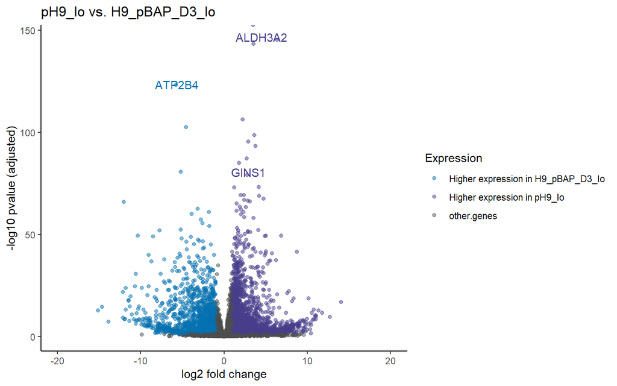

Fig 2.1: pH9_Io vs. H9_pBAP_D3_Io

```r
volcanoPlots2(
  res.PH9vsBAP,
  "PH9vsBAP",
  "pH9_Io",
  "H9_pBAP_D3_Io",
  "#0571B0",
  "#483D8B",
  "#4d4d4d",
  ChartTitle = "pH9_Io vs. H9_pBAP_D3_Io"
)
```

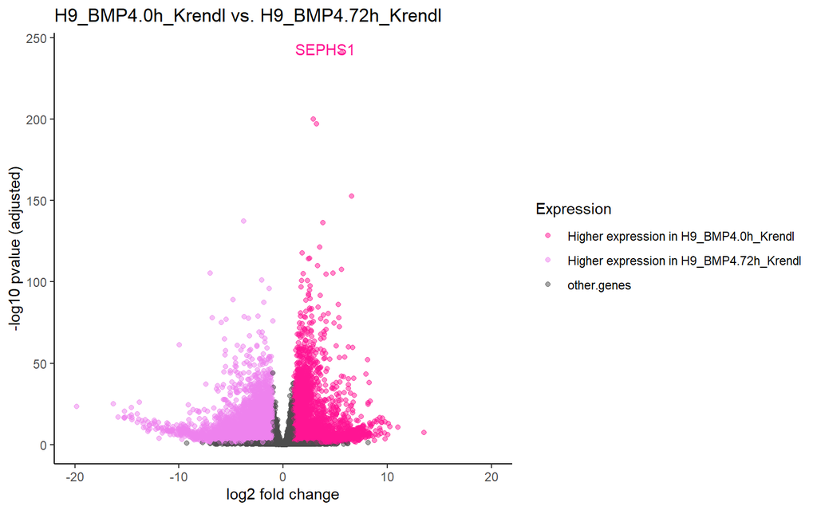

Fig 2.2: H9_BMP4.0h_Krendl vs. H9_BMP4.72h_Krendl

```r
volcanoPlots2(
  res.K00vsK72,
  "K00vsK72",
  "H9_BMP4.0h_Krendl",
  "H9_BMP4.72h_Krendl",
  "#FF1493",
  "#EE82EE",
  "#4d4d4d",
  ChartTitle = "H9_BMP4.0h_Krendl vs. H9_BMP4.72h_Krendl"
)
```

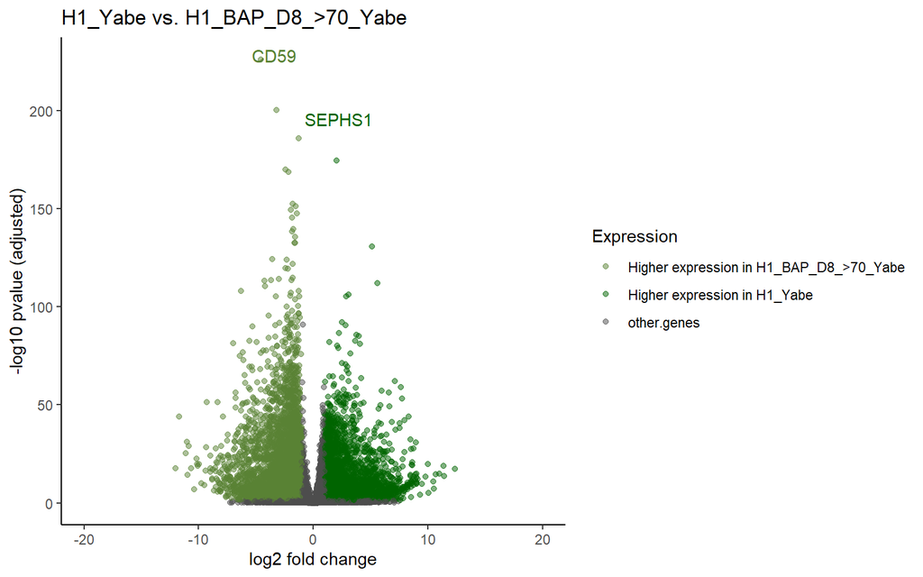

Fig 2.3: H1_Yabe vs. H1_BAP_D8_>70_Yabe

```r
volcanoPlots2(
  res.UNDvsSTB,
  "UNDvsSTB",
  "H1_Yabe",
  "H1_BAP_D8_>70_Yabe",
  "#598234",
  "#006400",
  "#4d4d4d",
  ChartTitle = "H1_Yabe vs. H1_BAP_D8_>70_Yabe"
)
```

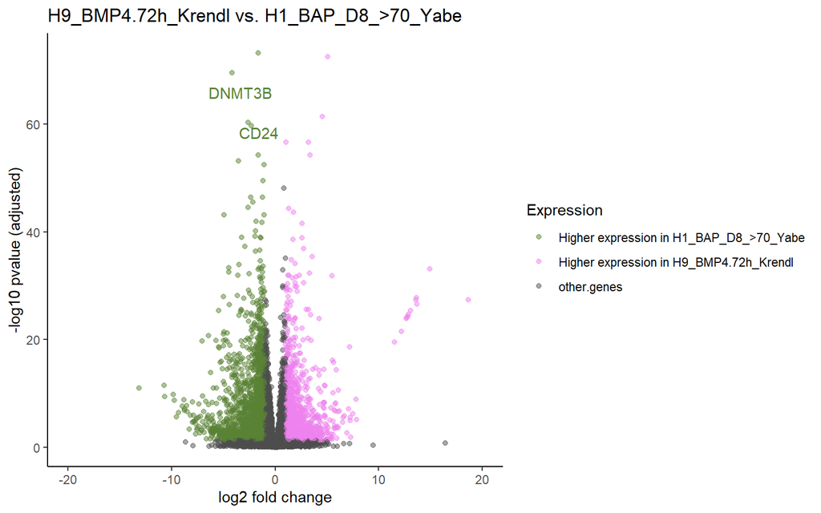

Fig 2.4: H9_BMP4.72h_Krendl vs. H1_BAP_D8_>70_Yabe

```r
volcanoPlots2(
  res.K72vsSTB,
  "K72vsSTB",
  "H9_BMP4.72h_Krendl",
  "H1_BAP_D8_>70_Yabe",
  "#598234",
  "#EE82EE",
  "#4d4d4d",
  ChartTitle = "H9_BMP4.72h_Krendl vs. H1_BAP_D8_>70_Yabe"
)
```

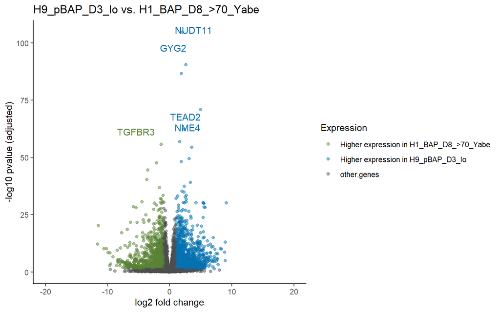

Fig 2.5: H9_pBAP_D3_Io vs. H1_BAP_D8_>70_Yabe

```r
volcanoPlots2(
  res.BAPvsSTB,
  "BAPvsSTB",
  "H9_pBAP_D3_Io",
  "H1_BAP_D8_>70_Yabe",
  "#598234",
  "#0571B0",
  "#4d4d4d",
  ChartTitle = "H9_pBAP_D3_Io vs. H1_BAP_D8_>70_Yabe"
)
```

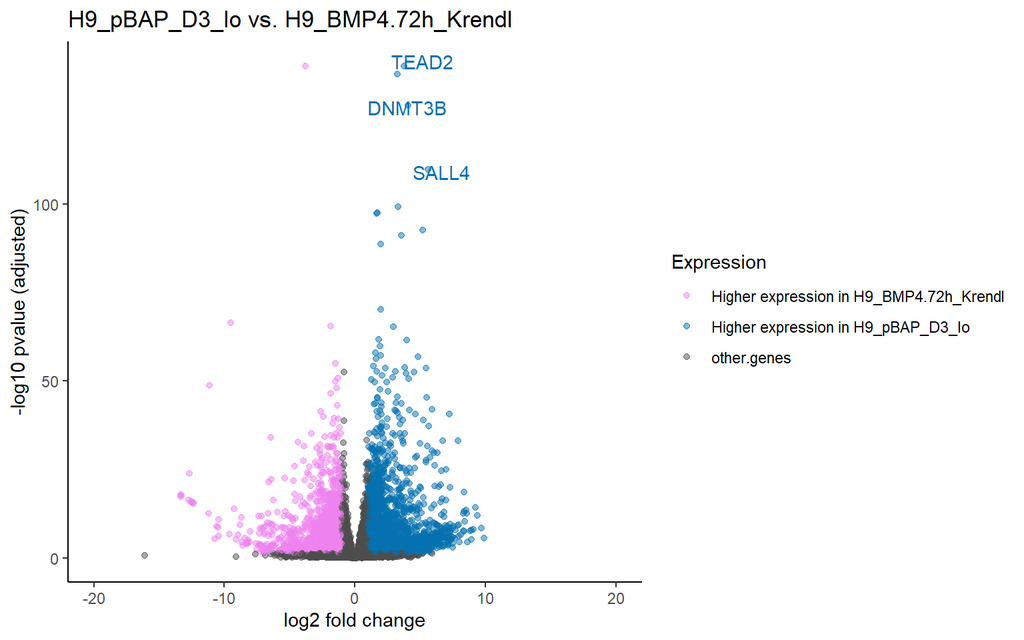

Fig 2.6: H9_pBAP_D3_Io vs. H9_BMP4.72h_Krendl

```r
volcanoPlots2(
  res.BAPvsK72,
  "BAPvsK72",
  "H9_pBAP_D3_Io",
  "H9_BMP4.72h_Krendl",
  "#EE82EE",
  "#0571B0",
  "#4d4d4d",
  ChartTitle = "H9_pBAP_D3_Io vs. H9_BMP4.72h_Krendl"
)
```

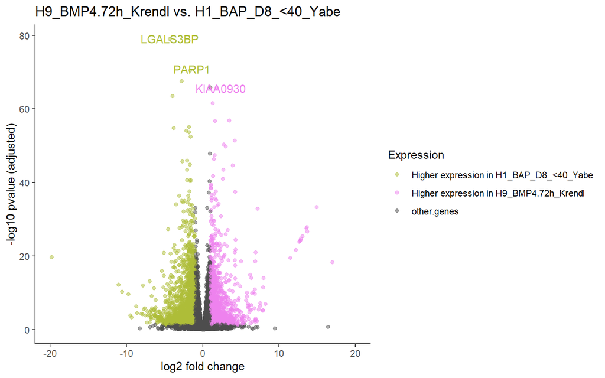

Fig 2.7: H9_BMP4.72h_Krendl vs. H1_BAP_D8_<40_Yabe

```r
volcanoPlots2(
  res.K72vsL40,
  "K72vsL40",
  "H9_BMP4.72h_Krendl",
  "H1_BAP_D8_<40_Yabe",
  "#AEBD38",
  "#EE82EE",
  "#4d4d4d",
  ChartTitle = "H9_BMP4.72h_Krendl vs. H1_BAP_D8_<40_Yabe"
)
```

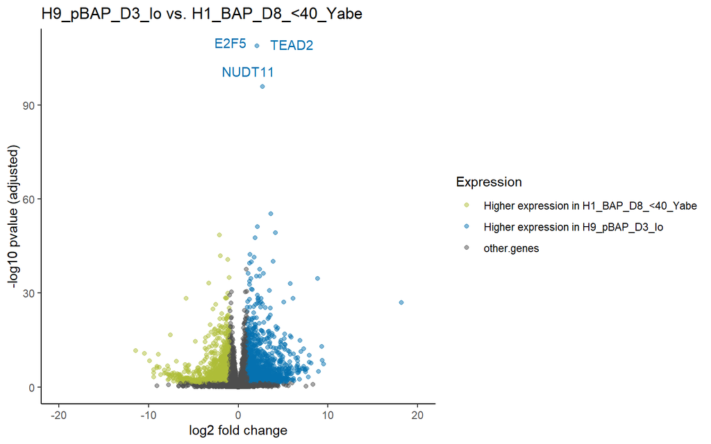

Fig 2.8: H9_pBAP_D3_Io vs. H1_BAP_D8_<40_Yabe

```r
volcanoPlots2(
  res.BAPvsL40,
  "BAPvsL40",
  "H9_pBAP_D3_Io",
  "H1_BAP_D8_<40_Yabe",
  "#AEBD38",
  "#0571B0",
  "#4d4d4d",
  ChartTitle = "H9_pBAP_D3_Io vs. H1_BAP_D8_<40_Yabe"
)
```

## PlacentaCellEnrich (PCE) analyses

The above gene lists are used for running PCE. The function used for running PCE is below.

```r
# Vento-Tormo et al., dataset
input = "C:/Users/arun/OneDrive - Iowa State University/OrganizedDocuments/TutejaLab/PlacentaEnrich/"
l <-
  load(file = paste0(input, "combine-test-expression1.Rdata"))
humanGeneMapping <- dataset$GRCH38$humanGeneMapping
d <- dataset$PlacentaDeciduaBloodData
data <- d$expressionData
cellDetails <- d$cellDetails
# Xiang et al., dataset
te.dataset.xiang <- readRDS(paste0(input, "te.dataset.xiang.rds"))
# Castel et al., dataset
te.dataset.castel <- readRDS(paste0(input, "te.dataset.castel.rds"))
# Ro dataset
te.dataset.ro <- readRDS(paste0(input, "te.Rostovskaya.exp0.01.fc1.rds"))

# full names for cell types
xi.md <-
  read.csv(
    paste0(input, "/md-xi.tsv"),
    sep = "\t",
    header = TRUE,
    row.names = 1
  )
vt.md <-
  read.csv(
    paste0(input, "md-vt.tsv"),
    sep = "\t",
    header = TRUE,
    row.names = 1
  )
zp.md <-
  read.csv(
    paste0(input, "md-zp.tsv"),
    sep = "\t",
    header = TRUE,
    row.names = 1
  )

ro.md <-
  read.csv(
    paste0(input, "md-ro.tsv"),
    sep = "\t",
    header = TRUE,
    row.names = 1
  )
```

```r
theme_clean <- function() {
  font.1 <- 'sans'   #assign font family up front
  font.2 <- 'sans'
  font.3 <- 'sans'
  theme_classic() %+replace%    #replace elements we want to change
    theme(
      #grid elements
      panel.grid.major = element_blank(),
      #strip major gridlines
      panel.grid.minor = element_blank(),
      #strip minor gridlines
      #panel.grid.major.x = element_blank(),
      #panel.grid.minor.x = element_blank(),
      #panel.grid.minor.y = element_blank(),
      #panel.grid.major.y = element_blank(),
      #panel.border = element_blank()
      #axis.ticks = element_blank(),          #strip axis ticks
      #since theme_minimal() already strips axis lines, we don't need to do that again
      # Plot Title
      plot.title = element_text(
        #title
        family = font.1,
        #set font family
        size = 14,
        #set font size
        face = 'bold',
        #bold typeface
        hjust = 0,
        #left align
        vjust = 2
      ),
      #raise slightly
      # Plot SubTitle
      plot.subtitle = element_text(#subtitle
        family = font.1,              #font family
        size = 12),
      #font size
      # Caption (bottom -right)
      plot.caption = element_text(
        #caption
        family = font.1,
        #font family
        size = 12,
        #font size
        hjust = 1
      ),
      #right align
      plot.margin = margin(
        t = 1,
        r = 1,
        b = 1,
        l = 2,
        unit = "cm"
      ),
      # Axis Title
      axis.title = element_text(
        family = font.1,
        size = 12,
        face = 'bold'
      ),
      axis.line.x = element_line(color = "black"),
      axis.line.y = element_line(color = "black"),
      axis.text = element_text(family = font.1,
                               size = 12),
      axis.text.x = element_text(#margin for axis text
        margin = margin(5, b = 10),
        size = 12),
      # FacetGrid title
      strip.text = element_text(
        family = font.1,
        face = "bold",
        color = "gray35",
        hjust = 0,
        size = 10
      ),
      # FacetGrid background
      strip.background = element_rect(fill = "white",
                                      linetype = "blank"),
      # Legend title
      legend.title = element_text(
        family = font.1,
        size = 12,
        color = "black",
        face = "bold"
      ),
      # Legend box contents
      legend.text = element_text(
        family = font.1,
        size = 12,
        color = "black",
        face = "plain"
      ),
      #legend.background = element_blank(),
      legend.background = element_rect(
        color = "black",
        fill = "transparent",
        size = 2,
        linetype = "blank"
      ),
      legend.key = element_blank(),
      #legend.position=c(0.05, 0.95),
      #legend.position="none",
      #legend.justification=c(0,1),
      #legend.key = element_blank(),
    )
}
```

```r
run.all.PCE <- function(geneList1, geneList2, filename, ChartTitle, barcolor) {
  inputGenes <- unique(toupper(geneList2))
  gs1 <- GeneSet(geneIds = inputGenes)
  humanGene <-
    humanGeneMapping[humanGeneMapping$Gene.name %in% inputGenes,]
  inputGenes <- humanGene$Gene
  expressionData <-
    data[intersect(row.names(data), humanGeneMapping$Gene),]
  se <-
    SummarizedExperiment(
      assays = SimpleList(as.matrix(expressionData)),
      rowData = row.names(expressionData),
      colData = colnames(expressionData)
    )
  cellSpecificGenesExp <-
    teGeneRetrieval(se, expressedGeneThreshold = 1)
  gs <- GeneSet(geneIds = toupper(inputGenes))
  output.vt <- teEnrichmentCustom(gs, cellSpecificGenesExp)
  en.output.vt <-
    setNames(data.frame(assay(output.vt[[1]]), row.names = rowData(output.vt[[1]])[, 1]),
             colData(output.vt[[1]])[, 1])
  row.names(cellDetails) <- cellDetails$RName
  en.output.vt$Tissue <-
    cellDetails[row.names(en.output.vt), "CellName"]
  en.output.vt$source <- "VT"
  en.output.vt <- en.output.vt[order(-en.output.vt$Log10PValue), ]
  en.output.vt <-
    merge(en.output.vt, vt.md, by = "row.names", all.x = TRUE)
  en.output.vt <- rownames_to_column(en.output.vt, var = "Name")
  output.xi <- teEnrichmentCustom(gs1, te.dataset.xiang)
  en.output.xi <-
    setNames(data.frame(assay(output.xi[[1]]), row.names = rowData(output.xi[[1]])[, 1]),
             colData(output.xi[[1]])[, 1])
  en.output.xi$Tissue <- rownames(en.output.xi)
  en.output.xi$source <- "Xi"
  en.output.xi <- en.output.xi[order(-en.output.xi$Log10PValue), ]
  en.output.xi <-
    merge(en.output.xi, xi.md, by = "row.names", all.x = TRUE)
  en.output.xi <- rownames_to_column(en.output.xi, var = "Name")
  output.zp <- teEnrichmentCustom(gs1, te.dataset.castel)
  en.output.zp <-
    setNames(data.frame(assay(output.zp[[1]]), row.names = rowData(output.zp[[1]])[, 1]),
             colData(output.zp[[1]])[, 1])
  en.output.zp$Tissue <- rownames(en.output.zp)
  en.output.zp$source <- "ZP"
  en.output.zp <- en.output.zp[order(-en.output.zp$Log10PValue), ]
  en.output.zp <-
    merge(en.output.zp, zp.md, by = "row.names", all.x = TRUE)
  en.output.zp <- rownames_to_column(en.output.zp, var = "Name")

  output.ro <- teEnrichmentCustom(gs1, te.dataset.ro)
  en.output.ro <-
    setNames(data.frame(assay(output.ro[[1]]), row.names = rowData(output.ro[[1]])[, 1]),
             colData(output.ro[[1]])[, 1])
  en.output.ro$Tissue <- rownames(en.output.ro)
  en.output.ro$source <- "Ro"
  en.output.ro <- en.output.ro[order(-en.output.ro$Log10PValue), ]
  en.output.ro <-
    merge(en.output.ro, ro.md, by = "row.names", all.x = TRUE)
#  colnames(en.output.ro) <- c("Name", "Log10PValue", "Tissue.Specific.Genes", "fold.change", "Tissue", "source", "CellNames")
  en.output.ro <- rownames_to_column(en.output.ro, var = "Name")


  en.conbined <- rbind(en.output.vt, en.output.xi, en.output.zp, en.output.ro)
  #  p <- 0.05
  #  logp <- -log10(p)
  en.conbined <-  en.conbined %>%
    #    mutate(Log10PValue = replace(Log10PValue, Log10PValue < logp, 0))
    #  en.conbined %>%
    group_by(source) %>%
    arrange(source, desc(Log10PValue)) %>% dplyr::slice(1:7)  %>%
    ungroup %>%
    mutate(
      source = as.factor(source),
      CellNames = tidytext::reorder_within(CellNames, Log10PValue, source, sep = ":")
    )
  # write.table(en.conbined,
  #             file = paste0("cluster_", filename, ".tsv"))

g <-
  ggplot(en.conbined, aes(CellNames, Log10PValue)) +
  geom_bar(stat = 'identity', fill = barcolor) +
  labs(x = "", y = "-log10(adj. p value)") +
  theme_clean() +
    ggtitle(ChartTitle) +
  theme(legend.position = "none",
        axis.title.y = element_blank()
  ) +
  scale_y_continuous(expand = expansion(mult = c(0, .1)), breaks = pretty_breaks()) +
  facet_wrap( ~ source, scales = "free", ncol = 2) +
  coord_flip()
ggsave(paste0("PCE_", filename, ".png"),
       g,
       dpi = 900,
       width = 12,
       height = 8
)
return(g)
}
```

The PCE is run on each of the gene lists as follows (up and down pairs are displayed together).

## PCE plots

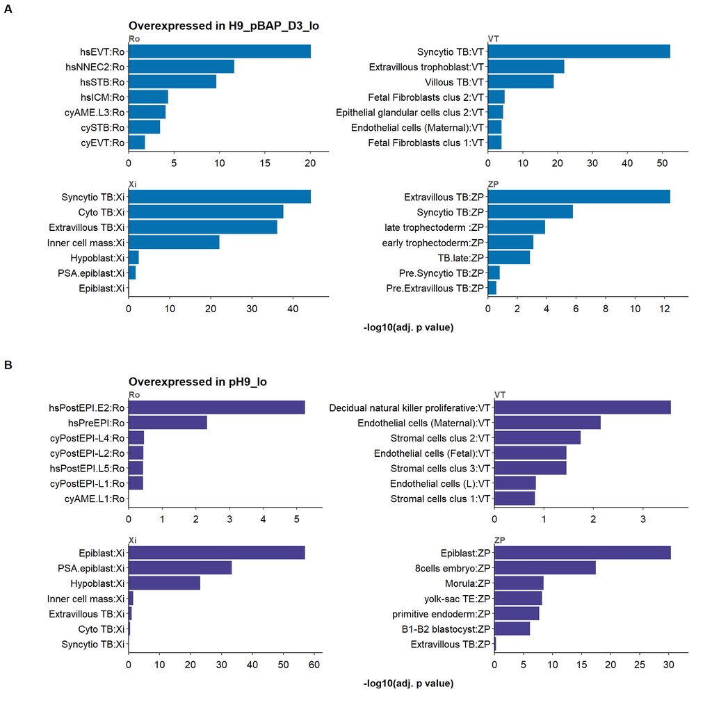

Fig 2.9: PCE results for pH9_Io vs. H9_pBAP_D3_Io

```r
a <-
  run.all.PCE(
    PH9vsBAP.dw.pce1,
    PH9vsBAP.dw.pce2,
    "PH9vsBAP.down_allPCE.v2",
    "Overexpressed in H9_pBAP_D3_Io",
    "#0571B0"
  )
b <-
  run.all.PCE(
    PH9vsBAP.up.pce1,
    PH9vsBAP.up.pce2,
    "PH9vsBAP.up_allPCE.v2",
    "Overexpressed in pH9_Io",
    "#483F8E"
  )
panel_plot <-
  plot_grid(a,
            b,
            labels = c("A", "B"),
            ncol = 1,
            nrow = 2)
panel_plot
```

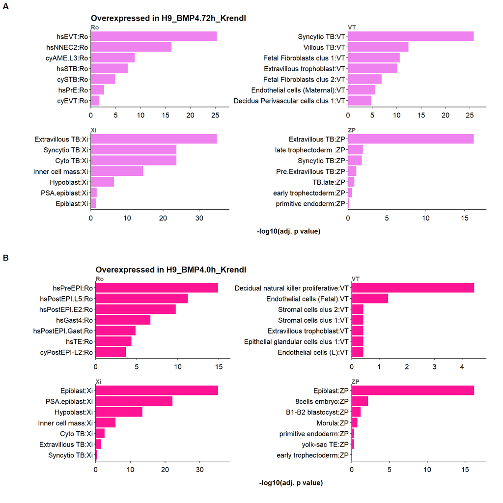

Fig 2.10: PCE results for H9_BMP4.0h_Krendl vs. H9_BMP4.72h_Krendl

```r
a <-
  run.all.PCE(
    K00vsK72.dw.pce1,
    K00vsK72.dw.pce2,
    "K00vsK72.down_allPCE.v2",
    "Overexpressed in H9_BMP4.72h_Krendl",
    "#EE82EE"
  )
b <-
  run.all.PCE(
    K00vsK72.up.pce1,
    K00vsK72.up.pce2,
    "K00vsK72.up_allPCE.v2",
    "Overexpressed in H9_BMP4.0h_Krendl",
    "#FF1493"
  )
panel_plot <-
  plot_grid(a,
            b,
            labels = c("A", "B"),
            ncol = 1,
            nrow = 2)
panel_plot
```

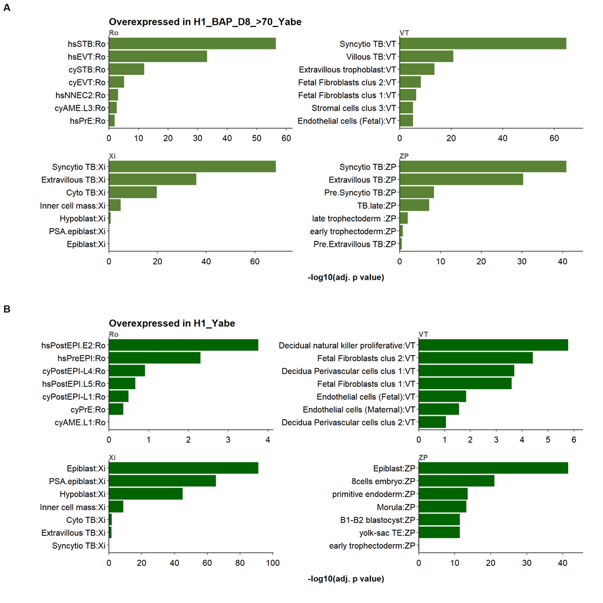

Fig 2.11: PCE results for H1_Yabe vs. H1_BAP_D8_>70_Yabe

```r
a <-
  run.all.PCE(
    UNDvsSTB.dw.pce1,
    UNDvsSTB.dw.pce2,
    "UNDvsSTB.down_allPCE.v2",
    "Overexpressed in H1_BAP_D8_>70_Yabe",
    "#598234"
  )
b <-
  run.all.PCE(
    UNDvsSTB.up.pce1,
    UNDvsSTB.up.pce2,
    "UNDvsSTB.up_allPCE.v2",
    "Overexpressed in H1_Yabe",
    "#006400"
  )
panel_plot <-
  plot_grid(a,
            b,
            labels = c("A", "B"),
            ncol = 1,
            nrow = 2)
panel_plot
```

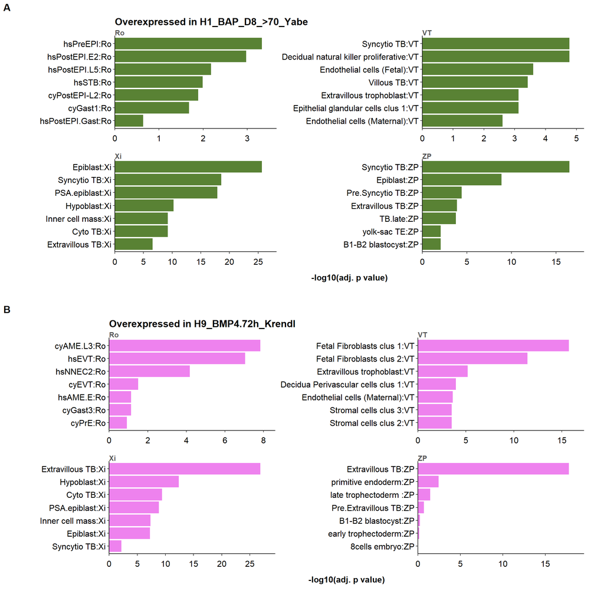

Fig 2.12: PCE results for H9_BMP4.72h_Krendl vs. H1_BAP_D8_>70_Yabe

```r
a <-
  run.all.PCE(
    K72vsSTB.dw.pce1,
    K72vsSTB.dw.pce2,
    "K72vsSTB.down_allPCE.v2",
    "Overexpressed in H1_BAP_D8_>70_Yabe",
    "#598234"
  )
b <-
  run.all.PCE(
    K72vsSTB.up.pce1,
    K72vsSTB.up.pce2,
    "K72vsSTB.up_allPCE.v2",
    "Overexpressed in H9_BMP4.72h_Krendl",
    "#EE82EE"
  )
panel_plot <-
  plot_grid(a,
            b,
            labels = c("A", "B"),
            ncol = 1,
            nrow = 2)
panel_plot
```

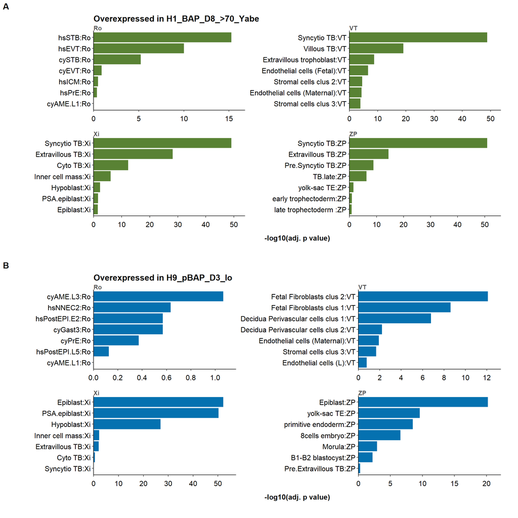

Fig 2.13: PCE results for H9_pBAP_D3_Io vs. H1_BAP_D8_>70_Yabe

```r
a <-
  run.all.PCE(
    BAPvsSTB.dw.pce1,
    BAPvsSTB.dw.pce2,
    "BAPvsSTB.down_allPCE.v2",
    "Overexpressed in H1_BAP_D8_>70_Yabe",
    "#598234"
  )
b <-
  run.all.PCE(
    BAPvsSTB.up.pce1,
    BAPvsSTB.up.pce2,
    "BAPvsSTB.up_allPCE.v2",
    "Overexpressed in H9_pBAP_D3_Io",
    "#0571B0"
  )
panel_plot <-
  plot_grid(a,
            b,
            labels = c("A", "B"),
            ncol = 1,
            nrow = 2)
panel_plot
```

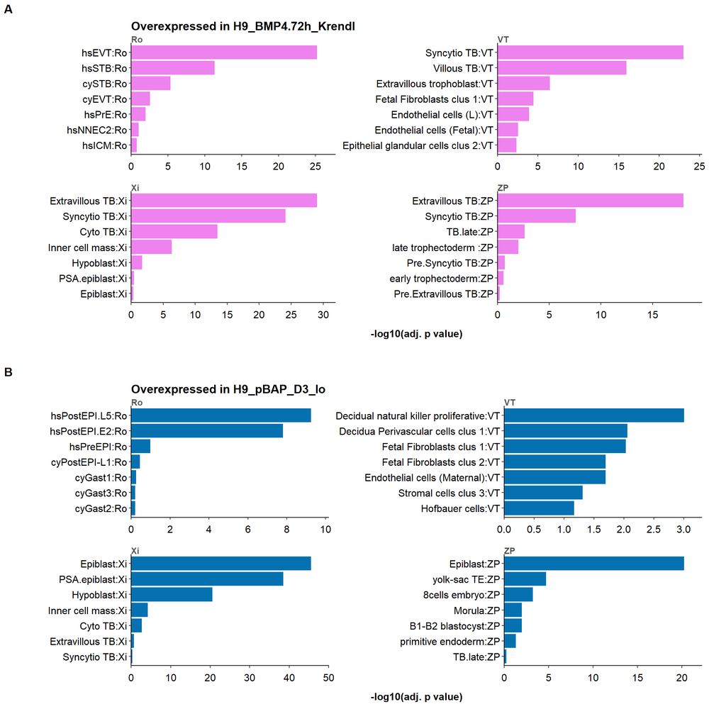

Fig 2.14: PCE results for H9_pBAP_D3_Io vs. H9_BMP4.72h_Krendl

```r
a <-
  run.all.PCE(
    BAPvsK72.dw.pce1,
    BAPvsK72.dw.pce2,
    "BAPvsK72.down_allPCE.v2",
    "Overexpressed in H9_BMP4.72h_Krendl",
    "#EE82EE"
  )
b <-
  run.all.PCE(
    BAPvsK72.up.pce1,
    BAPvsK72.up.pce2,
    "BAPvsK72.up_allPCE.v2",
    "Overexpressed in H9_pBAP_D3_Io",
    "#0571B0"
  )
panel_plot <-
  plot_grid(a,
            b,
            labels = c("A", "B"),
            ncol = 1,
            nrow = 2)
panel_plot
```

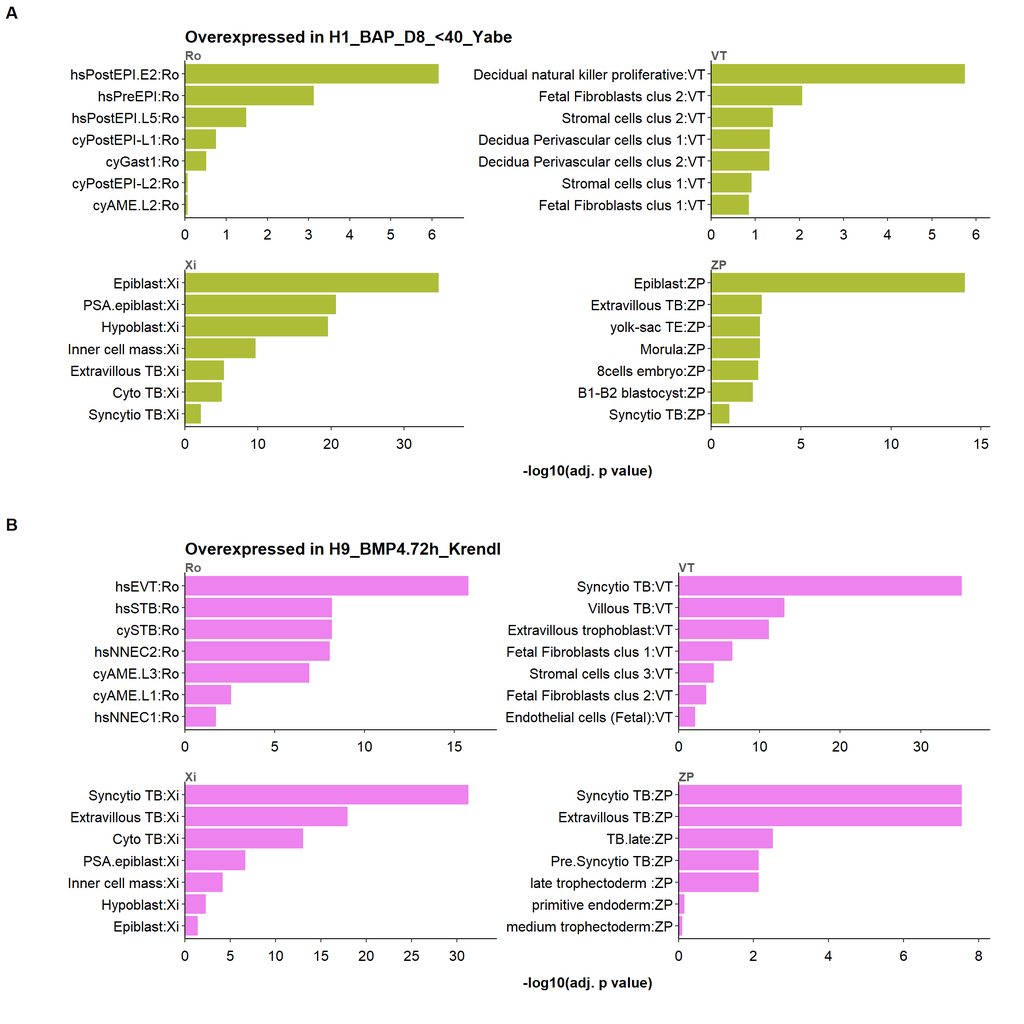

Fig 2.15: PCE results for H9_BMP4.72h_Krendl vs. H1_BAP_D8_<40_Yabe

```r
a <-
  run.all.PCE(
    K72vsL40.dw.pce1,
    K72vsL40.dw.pce2,
    "K72vsL40.down_allPCE.v2",
    "Overexpressed in H1_BAP_D8_<40_Yabe",
    "#AEBD38"
  )
b <-
  run.all.PCE(
    K72vsL40.up.pce1,
    K72vsL40.up.pce2,
    "K72vsL40.up_allPCE.v2",
    "Overexpressed in H9_BMP4.72h_Krendl",
    "#EE82EE"
  )
panel_plot <-
  plot_grid(a,
            b,
            labels = c("A", "B"),
            ncol = 1,
            nrow = 2)
panel_plot
```

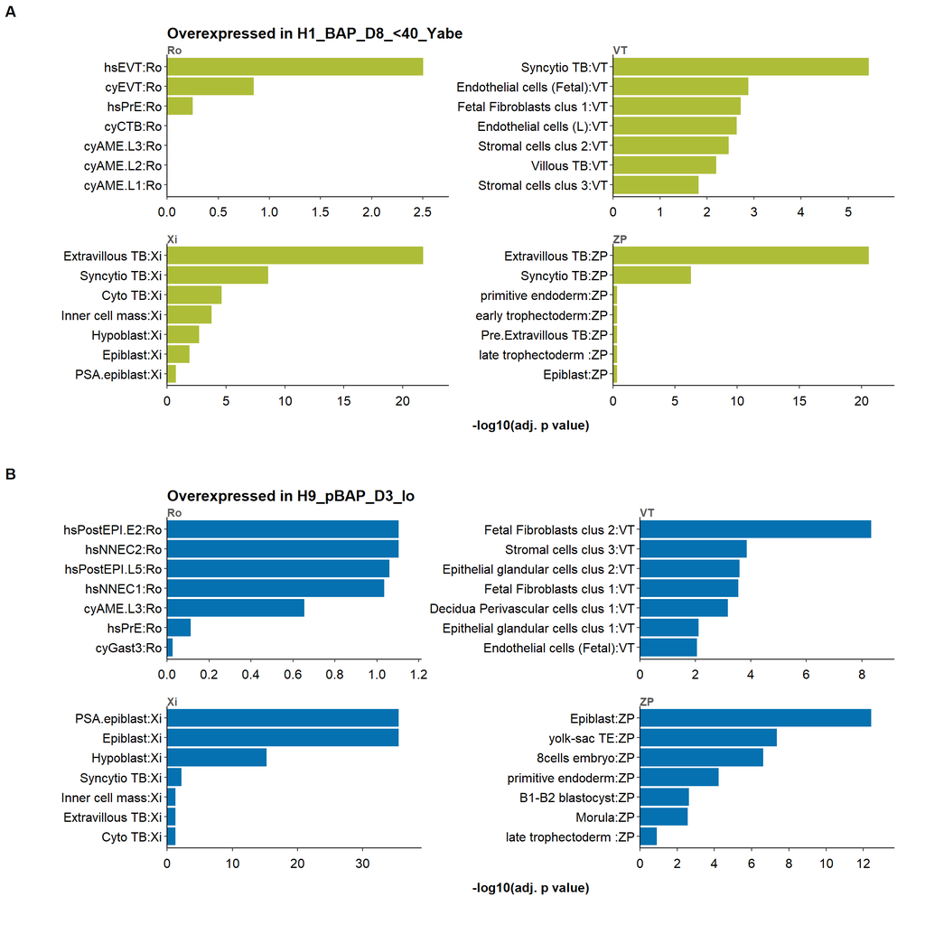

Fig 2.16: PCE results for H9_pBAP_D3_Io vs. H1_BAP_D8_<40_Yabe

```r
a <-
  run.all.PCE(
    BAPvsL40.dw.pce1,
    BAPvsL40.dw.pce2,
    "BAPvsL40.down_allPCE.v2",
    "Overexpressed in H1_BAP_D8_<40_Yabe",
    "#AEBD38"
  )
b <-
  run.all.PCE(
    BAPvsL40.up.pce1,
    BAPvsL40.up.pce2,
    "BAPvsL40.up_allPCE.v2",
    "Overexpressed in H9_pBAP_D3_Io",
    "#0571B0"
  )
panel_plot <-
  plot_grid(a,
            b,
            labels = c("A", "B"),
            ncol = 1,
            nrow = 2)
panel_plot
```